# 36-315 Homework 05, Spring 2019

# Problem 3

```r
wine <- read_csv("https://raw.githubusercontent.com/mateyneykov/315_code_data/master/data/wineQualityReds.csv")
```

**Density Estimates vs. Histograms**

1. It is the content of citric acid, in g / dm^3
2. The plot with smaller bandwidth is more jagged but shows very detailed features in the density. The other plot is much smoother and shows overall features in the density better but with less detail.

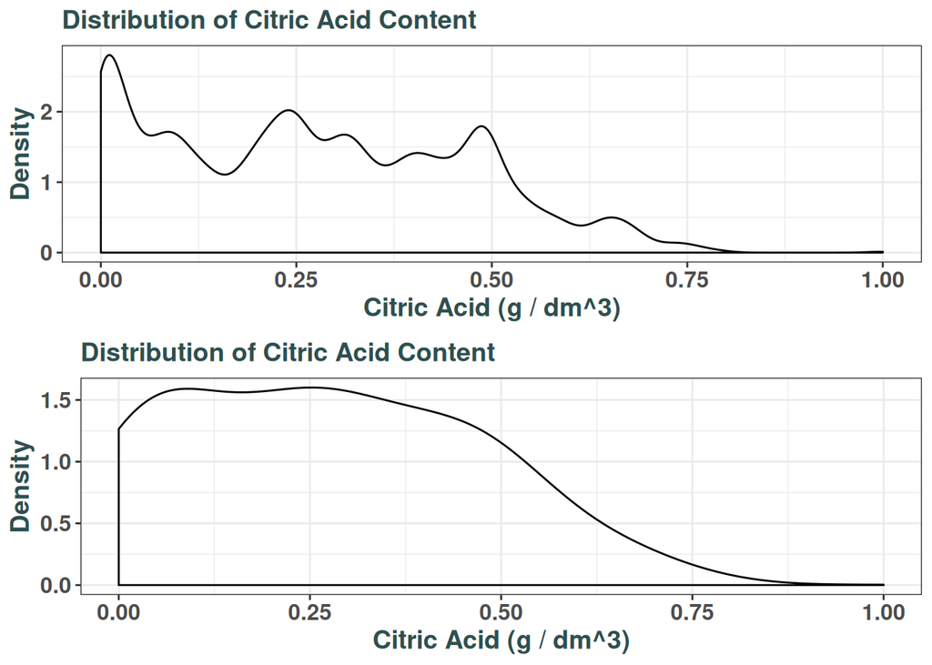

```r
library(tidyverse)
library(gridExtra)

glabs <- labs(
    x = "Citric Acid (g / dm^3)", y = "Density",
    title = "Distribution of Citric Acid Content")

g1 <- ggplot(wine, aes(x = citric.acid)) +
    geom_density(adjust = 0.5) +
    glabs + eujingc_315_theme
g2 <- ggplot(wine, aes(x = citric.acid)) +
    geom_density(adjust = 2.0) +
    glabs + eujingc_315_theme

grid.arrange(g1, g2, nrow = 2)
```

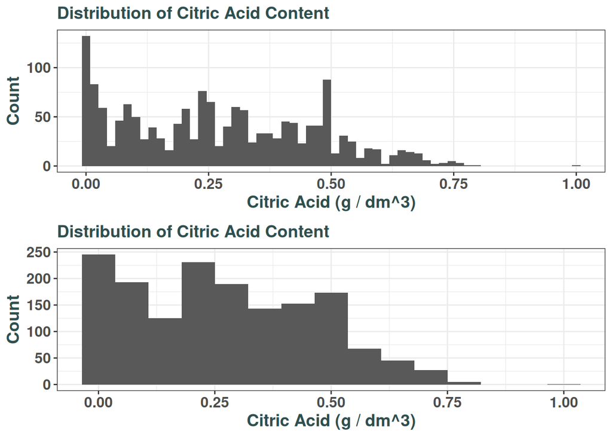

```r
glabs <- labs(
    x = "Citric Acid (g / dm^3)", y = "Count",
    title = "Distribution of Citric Acid Content")

g1 <- ggplot(wine, aes(x = citric.acid)) +
    geom_histogram(bins = 60) +
    glabs + eujingc_315_theme
g2 <- ggplot(wine, aes(x = citric.acid)) +
    geom_histogram(bins = 15) +
    glabs + eujingc_315_theme

grid.arrange(g1, g2, nrow = 2)
```

The plot with more bins shows more detailed features about the density but with many gaps in-between peaks, making it hard to interpret larger-scale features in the density. The other plot with less bins is smoother and makes it easier to see the density overall but with much less detailed features.

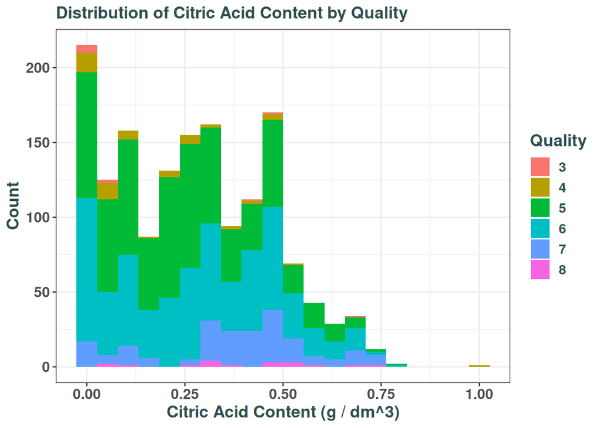

```r
glabs <- labs(x = "Citric Acid Content (g / dm^3)",
              title = "Distribution of Citric Acid Content by Quality")
g1 <- ggplot(wine, aes(x = citric.acid, fill = factor(quality))) +
    geom_histogram(bins = 20) +
    glabs + labs(y = "Count", fill = "Quality") + eujingc_315_theme
g1
```

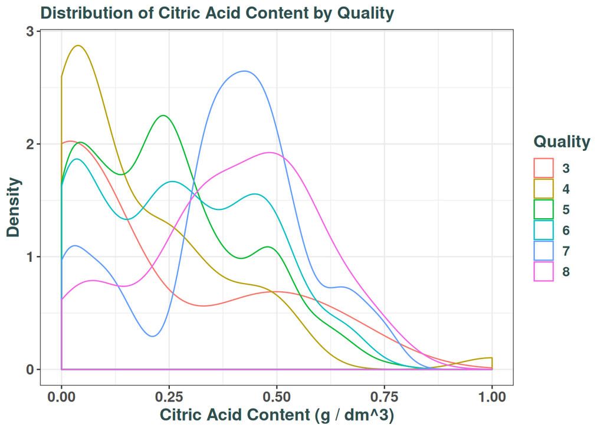

```r
g2 <- ggplot(wine, aes(x = citric.acid, color = factor(quality))) +
    geom_density() +
    glabs + labs(y = "Density", color = "Quality") + eujingc_315_theme
g2
```

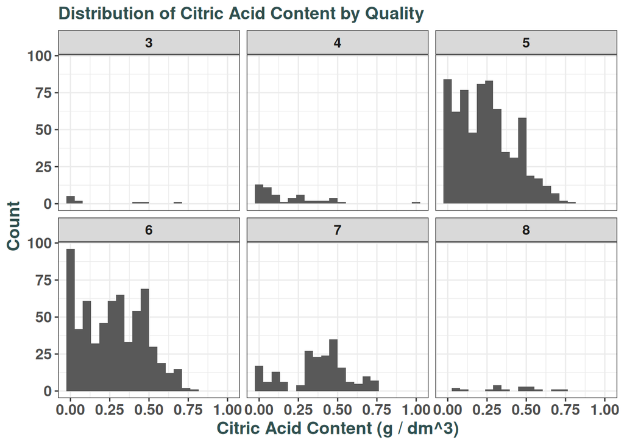

```r
g3 <- ggplot(wine, aes(x = citric.acid)) +
    geom_histogram(bins = 20) +
    facet_wrap(~ factor(quality)) +
    glabs + labs(y = "Count") + eujingc_315_theme
g3
```

5. Both ways make sense, as in 6 columns we can easily compare their relative counts, but in 6 rows we can compare which locations have more density more easily.

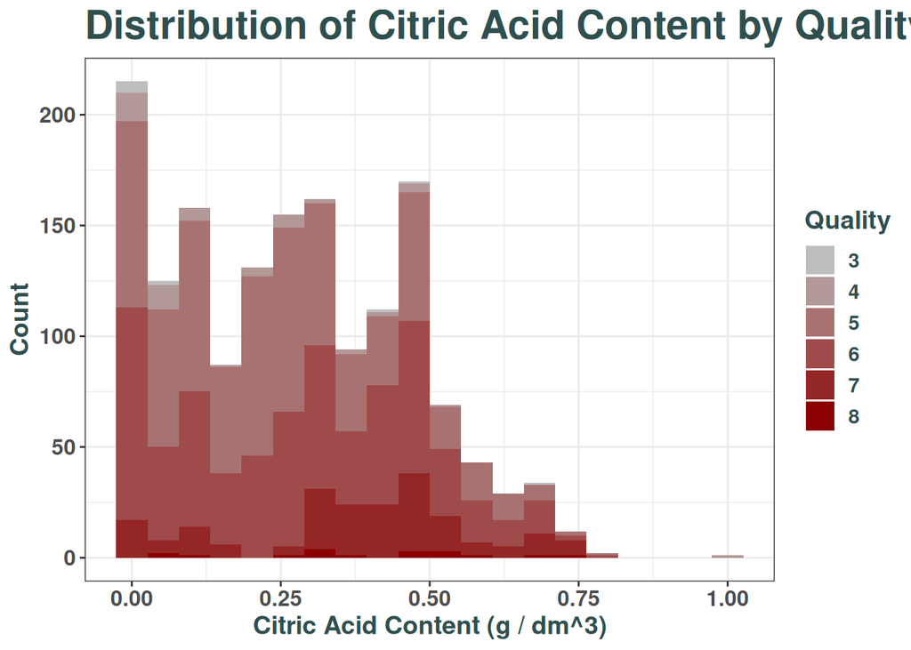

```r
wine <- wine %>% mutate(quality = factor(quality))

glabs <- labs(x = "Citric Acid Content (g / dm^3)",
              title = "Distribution of Citric Acid Content by Quality")
palette <- c("grey", "darkred")
n_values <- length(unique(wine$quality))

g1 <- ggplot(wine, aes(x = citric.acid, fill = factor(quality))) +
    geom_histogram(bins = 20) +
    glabs + labs(y = "Count", fill = "Quality") +
    eujingc_315_theme +
    scale_fill_manual(name = "Quality",
                      values = colorRampPalette(palette)(n_values))
g1
```

# Problem 4

1. The content of potassium sulfur dioxide in g / dm^3

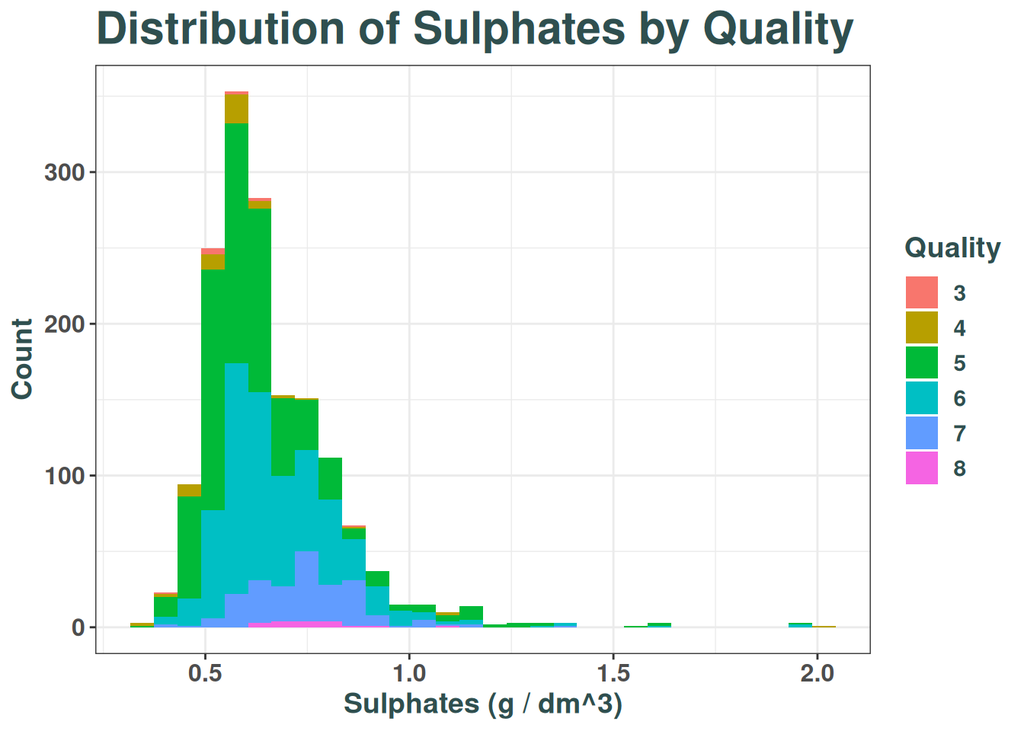

```r
ggplot(wine, aes(x = sulphates, fill = quality)) +
    geom_histogram() +
    labs(x = "Sulphates (g / dm^3)", y = "Count", fill = "Quality",
         title = "Distribution of Sulphates by Quality") +
         eujingc_315_theme
```

The distribution is roughly centered around 0.6 with quite low spread. It is uni-modal with a right skew.

3. The answer is clearer here than in b) as we can see that higher quality wines tend to have higher sulphate content overall.

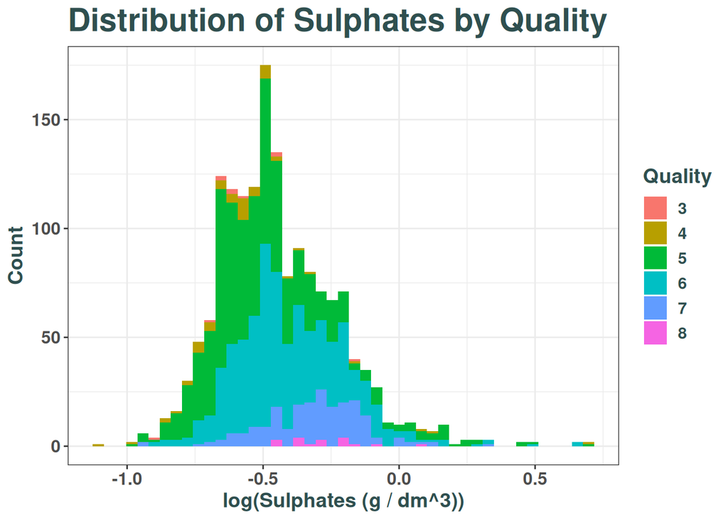

```r
ggplot(wine, aes(x = log(sulphates), fill = quality)) +
    geom_histogram(bins = 45) +
    labs(x = "log(Sulphates (g / dm^3))", y = "Count", fill = "Quality",
         title = "Distribution of Sulphates by Quality") +
         eujingc_315_theme
```

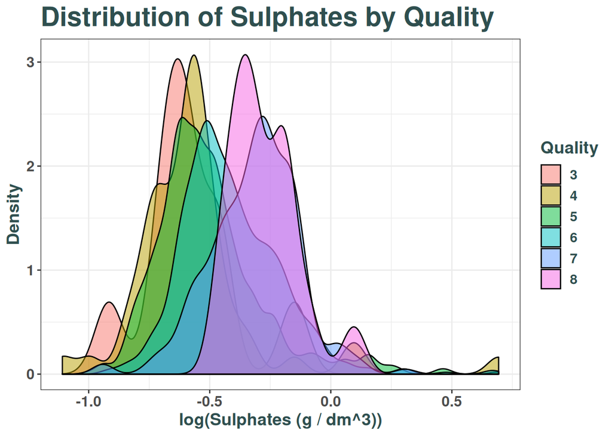

```r
ggplot(wine, aes(x = log(sulphates), fill = quality)) +
    geom_density(adjust = 0.75, alpha = 0.5) +
    labs(x = "log(Sulphates (g / dm^3))", y = "Density", fill = "Quality",
         title = "Distribution of Sulphates by Quality") +
         eujingc_315_theme
```

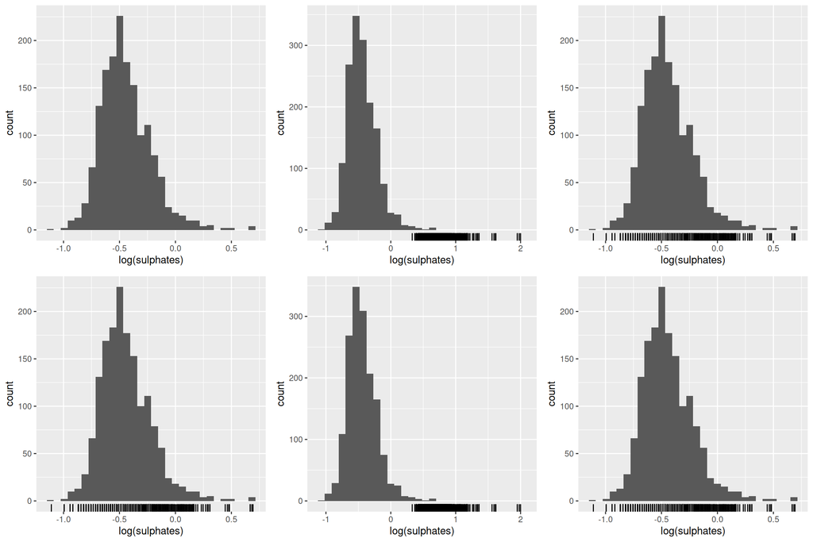

```r
library(gridExtra)
plot1 <- ggplot(wine) +
    geom_histogram(aes(x = log(sulphates))) +
    geom_rug()
plot2 <- ggplot(wine) +
    geom_histogram(aes(x = log(sulphates))) +
    geom_rug(aes(x = sulphates))
plot3 <- ggplot(wine) +
    geom_histogram(aes(x = log(sulphates))) +
    geom_rug(aes(x = log(sulphates)))
plot4 <- ggplot(wine, aes(x = log(sulphates))) +
    geom_histogram() +
    geom_rug()
plot5 <- ggplot(wine, aes(x = log(sulphates))) +
    geom_histogram() +
    geom_rug(aes(x = sulphates))
plot6 <- ggplot(wine, aes(x = log(sulphates))) +
    geom_histogram() +
    geom_rug(aes(x = log(sulphates)))

grid.arrange(plot1, plot2, plot3, plot4, plot5, plot6, ncol = 3)
```

The first plot does not have rug plots as we did not map anything to `x` in aesthetics for the rug plot. The middle column plots look different as we did not apply the log transform to the data being mapped to `x` in the rug plot, but did in the histogram plot.  
The code for plot 4 is the most efficient and appropriate to use as it ensures we use the same transformed data for all layers.

6. Either the `scale_x_log10()` or `scale_x_sqrt()` functions.

Use `scale_x_continuous()` with `trans = "atanh"`.

# Problem 5

**Automatically Specify Bin Width**

```r
auto_binwidth <- function(x, adjust = 1) {
  #  your code should calculate a desired bin width, called "binwidth"
  #  given features of x, the input variable
  #  your function should return the binwidth times an adjustment factor
  #  that is specified by the user
  x_iqr <- IQR(x, na.rm = TRUE)
  x_count <- length(x)
  return(adjust * 1.75 * (x_iqr / x_count ^ (1 / 3)))
}
```

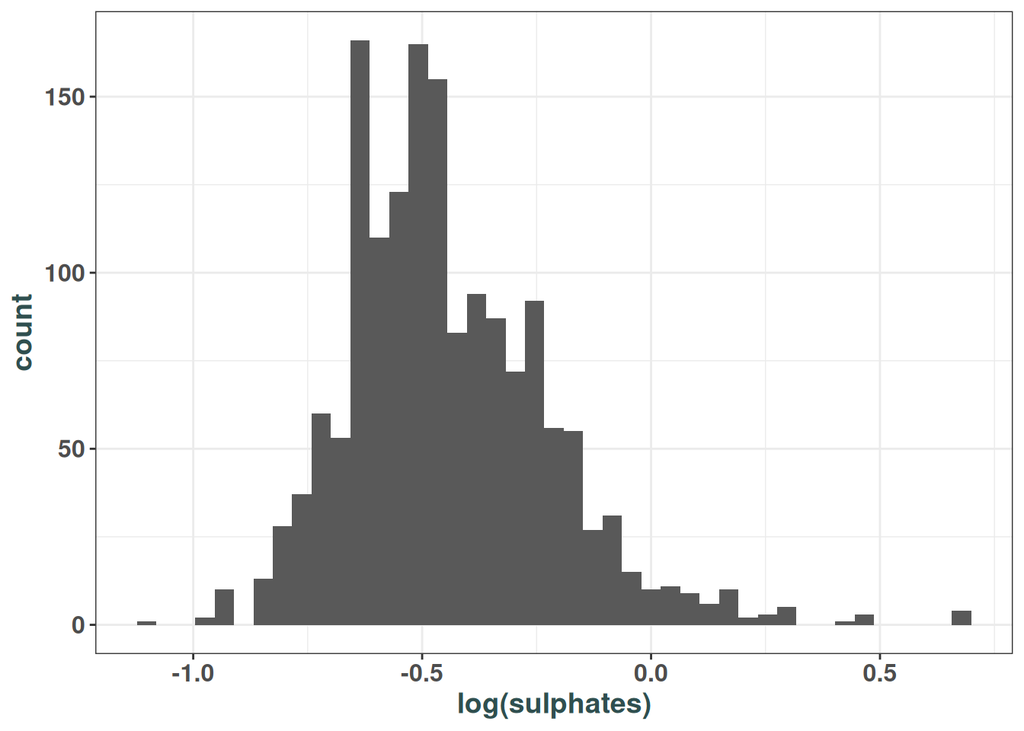

```r
ggplot(wine, aes(x = log(sulphates))) +
    geom_histogram(binwidth = auto_binwidth(log(wine$sulphates))) +
    eujingc_315_theme
```

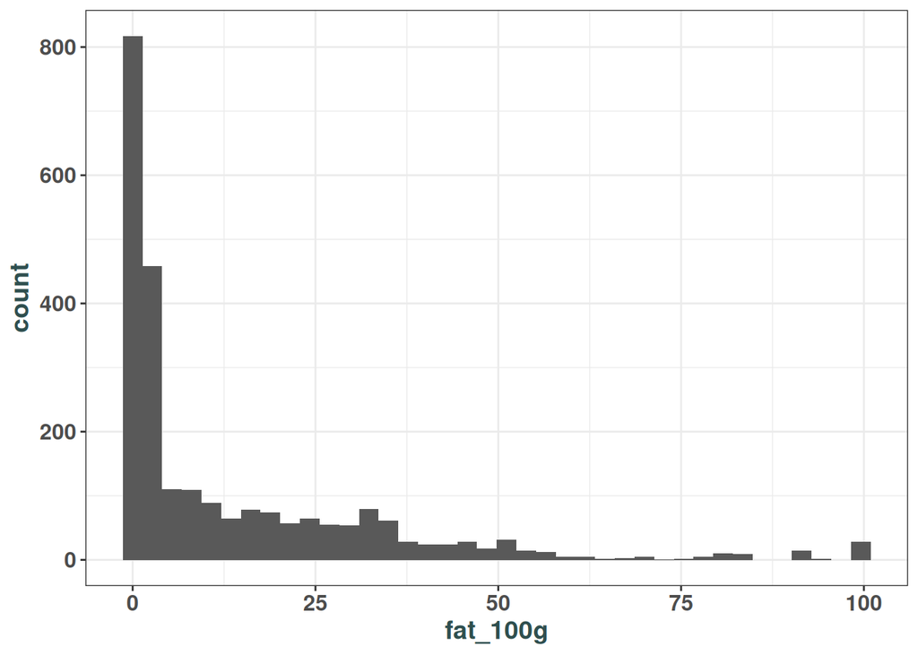

```r
food <- read_csv("https://raw.githubusercontent.com/mateyneykov/315_code_data/master/data/food-facts.csv")

ggplot(food, aes(x = fat_100g)) +
    geom_histogram(binwidth = auto_binwidth(food$fat_100g)) +
    eujingc_315_theme
```

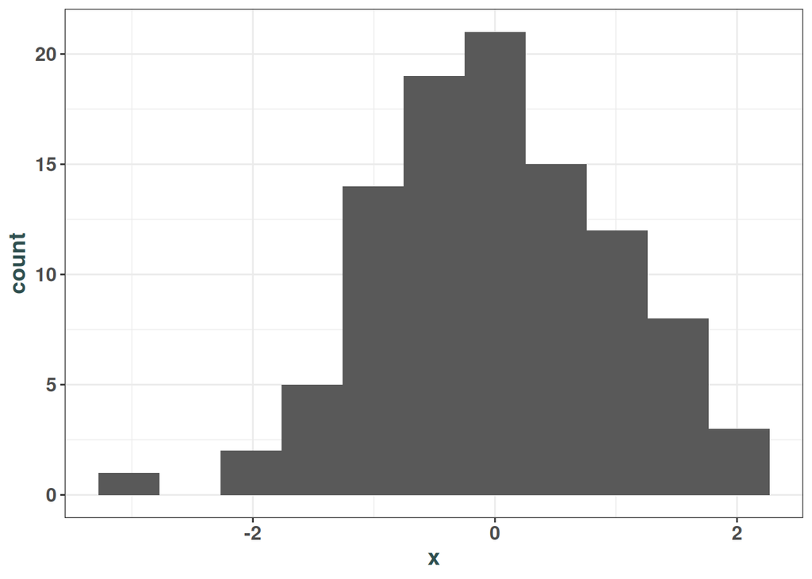

```r
df <- data.frame(x = rnorm(100))
ggplot(df, aes(x = x)) +
    geom_histogram(binwidth = auto_binwidth(df$x)) +
    eujingc_315_theme
```

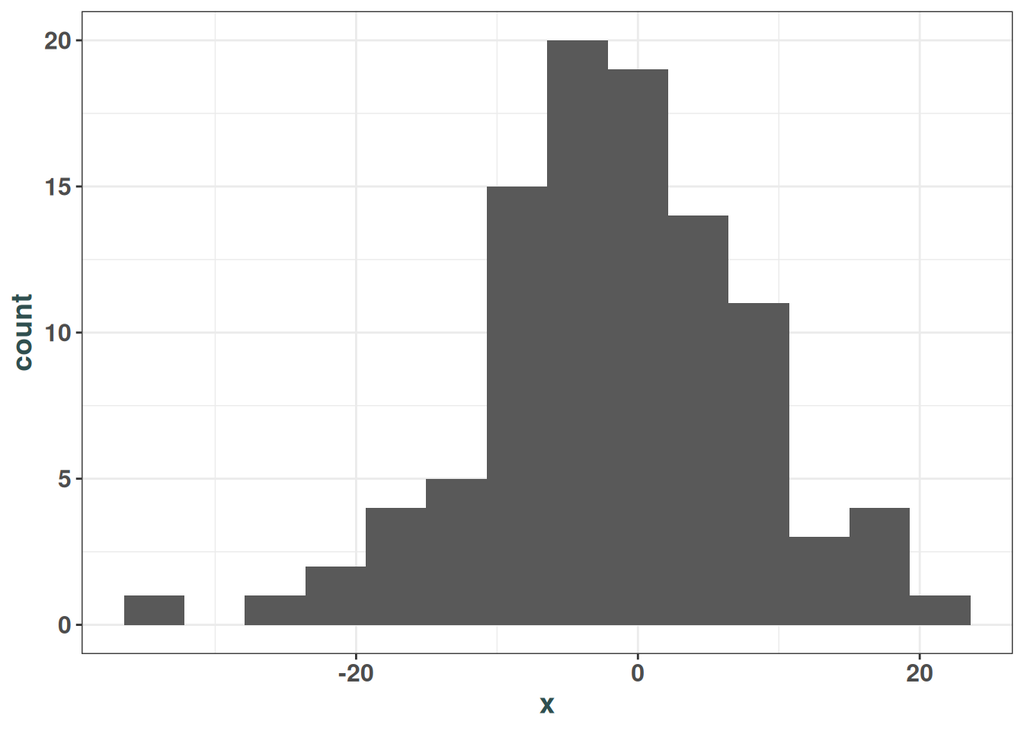

```r
df <- data.frame(x = rnorm(100, 0, 10))
ggplot(df, aes(x = x)) +
    geom_histogram(binwidth = auto_binwidth(df$x)) +
    eujingc_315_theme
```

# Practice Exam Questions

## Problem 6

**All About Content**

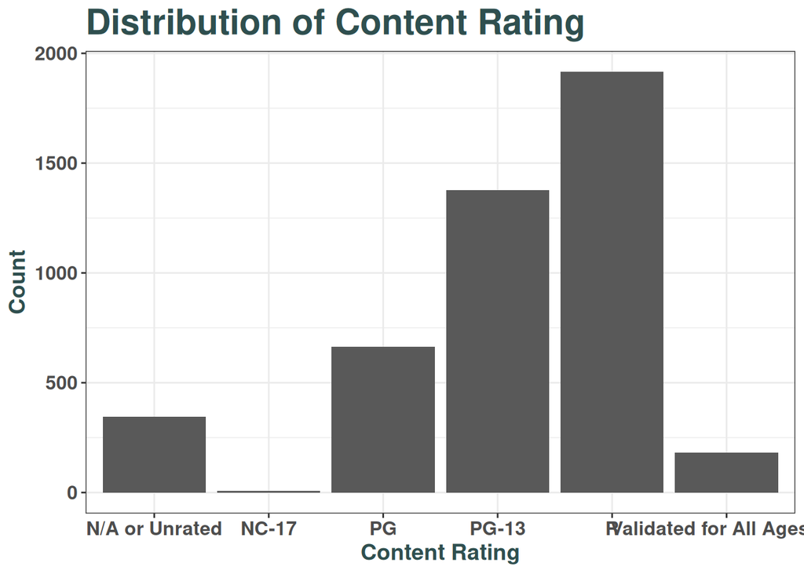

```r
movies <- read_csv("https://raw.githubusercontent.com/mateyneykov/315_code_data/master/data/imdb_test.csv")

ggplot(movies, aes(x = content_rating)) +
    geom_bar() +
    labs(x = "Content Rating", y = "Count",
         title = "Distribution of Content Rating") +
    eujingc_315_theme
```

There are very little movies of NC-17 in comparison to all other ratings, while the R rating has the highest count in this data set.

```r
movies <- movies  %>% mutate(comedy = grepl("Comedy", genres))
```

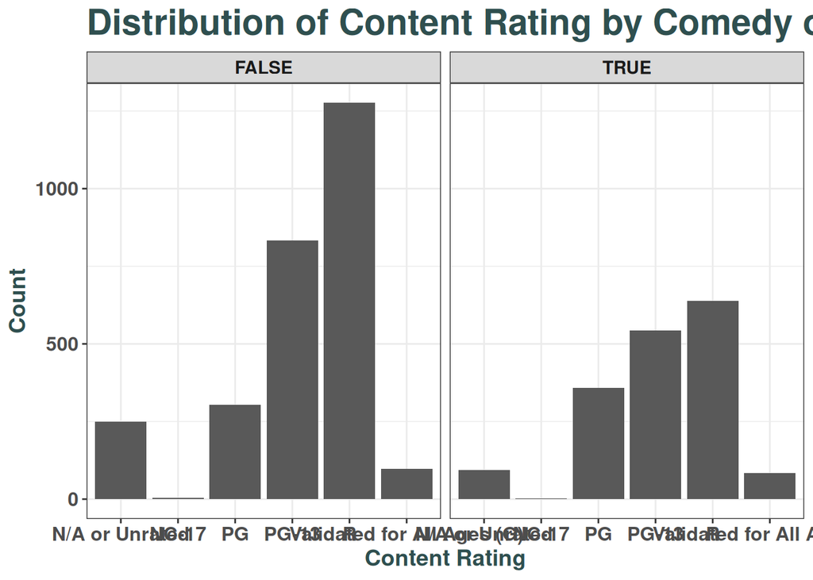

```r
ggplot(movies, aes(x = content_rating)) +
    facet_wrap(~ comedy) +
    geom_bar() +
    eujingc_315_theme +
    labs(x = "Content Rating", y = "Count",
         title = "Distribution of Content Rating by Comedy or Not")
```

3. PG shows have the highest proportion of comedies, as the plot shows the proportion of comedies in each content rating, and PG has the highest above 0.5.

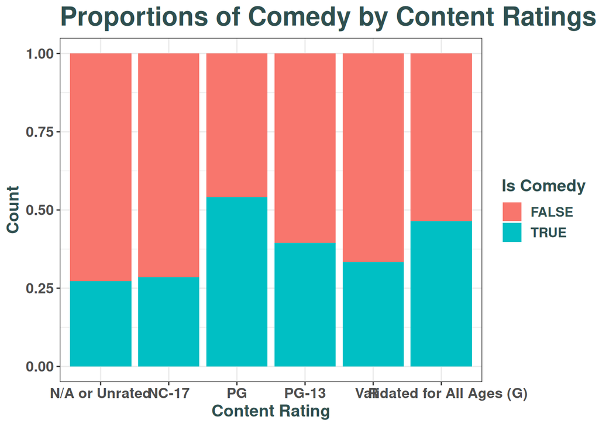

```r
ggplot(movies, aes(x = content_rating, fill = comedy)) +
    geom_bar(position = "fill") +
    eujingc_315_theme +
    labs(x = "Content Rating", y = "Count", fill = "Is Comedy",
         title = "Proportions of Comedy by Content Ratings")
```

```r
with(movies, chisq.test(table(content_rating, comedy)))
```

```
##
##  Pearson's Chi-squared test
##
## data:  table(content_rating, comedy)
## X-squared = 113.75, df = 5, p-value < 2.2e-16
```

We use a chi-square test for independence, with the null hypothesis that content rating is independent of whether the movie is a comedy. However, the p-value shows with 0.95 significance that we have enough evidence to reject the null and conclude they are not independent.

5. I chose a bar plot because we want to see the distribution of a discrete variable. To look at its conditional distributions, I used facetting to more easily show the conditional distributions separately. Finally, I used a bar plot of proportions to look at the proportions of comedies across each content rating.

## Problem 7

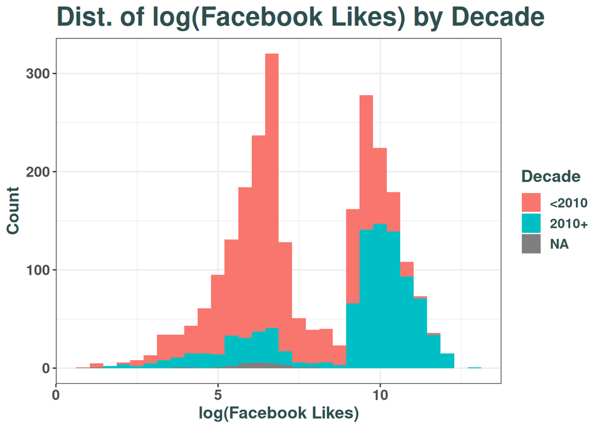

```r
movies <- mutate(
    movies,
    last_decade = factor(ifelse(title_year >= 2010, "2010+", "<2010")))
ggplot(movies, aes(x = log(movie_facebook_likes), fill = last_decade)) +
    geom_histogram() +
    labs(x = "log(Facebook Likes)", y = "Count",
         fill = "Decade",
         title = "Dist. of log(Facebook Likes) by Decade") +
    eujingc_315_theme
```